# Load the package

Simple case to discover the principles of Direct Probabilistic Pairing. It illustrates how to use this method to generate populations of dwellings and households, both being composed inside each other depending to their characteristics.

## Load the package

```r
# load the package from current directory (development mode)
library(devtools)
load_all()
```

```
#> Loading gosp.dpp
```

```r
# install on a local computer:
# library(gosp.dpp)
```

## Input data

The data to run this case is included in the package. Let's load it and have a look to its content.

```r
data(dwellings_households)
dwellings_households
```

```
#> $sample.A
#> Sample containing 1000 elements having 2 columns:surface,cost.per.month (weight column:weight)
#>
#> $sample.B
#> Sample containing 834 elements having 2 columns:size,income (weight column:weight)
#>
#> $pdi
#> distribution of degrees depending to attributes 'surface':
#>   surface=1 surface=2 surface=3
#> 0       0.2      0.15      0.05
#> 1       0.8      0.80      0.80
#> 2       0.0      0.05      0.10
#> 3       0.0      0.00      0.05
#> 4       0.0      0.00      0.00
#>
#> $pdj
#> distribution of degrees depending to attributes 'size':
#>   size=1 size=2 size=3 size=4
#> 0      0      0      0      0
#> 1      1      1      1      1
#>
#> $pij
#> matching probabilities given 'surface' and 'size':
#>        surface=1 surface=2 surface=3
#> size=1     0.200    0.0375    0.0125
#> size=2     0.100    0.1250    0.0250
#> size=3     0.050    0.1000    0.1000
#> size=4     0.025    0.0500    0.1750
```

The data required for the generation of a synthetic population made of paired entities is made of the elements displayed there. We describe in detail each type of data below.

### Samples for A and B

Two samples are provided for each entities. These samples are microdata, similar to PUMS.

The sample A contains a sample of dwellings, characterised by a surface category and a cost per month:

```r
dwellings_households$sample.A
```

```
#> Sample containing 1000 elements having 2 columns:surface,cost.per.month (weight column:weight)
```

```r
head(as.data.frame(dwellings_households$sample.A))
```

```
#>   id weight surface cost.per.month
#> 1  1      1       1              1
#> 2  2      1       2              7
#> 3  3      1       1              2
#> 4  4      1       3              4
#> 5  5      1       1              5
#> 6  6      1       1              8
```

The sample B contains a sample of households, characterised by a size (count of people) and an income level:

```r
dwellings_households$sample.B
```

```
#> Sample containing 834 elements having 2 columns:size,income (weight column:weight)
```

```r
head(as.data.frame(dwellings_households$sample.B))
```

```
#>      weight size income
#> 1 0.6221325    4      8
#> 2 0.0461008    1      7
#> 3 0.6410418    3      1
#> 4 0.5819707    4      2
#> 5 0.5628794    1      5
#> 6 0.5361347    1      1
```

### Probability distributions for degrees

Input data also includes the description of how many links to create for each entity type given its characteristics. Here for dwellings, the count of links (in rows) depends on the attribute `surface` (in columns). This distribution means that for dwellings having surface 1 (first column), 20% have no link (so have no link with any household, aka empty) and 80% contain 1 household only. This table describes the fact smaller dwellings tend to host only one household, whilst bigger ones can contain several households.

```r
dwellings_households$pdi
```

```
#> distribution of degrees depending to attributes 'surface':
#>   surface=1 surface=2 surface=3
#> 0       0.2      0.15      0.05
#> 1       0.8      0.80      0.80
#> 2       0.0      0.05      0.10
#> 3       0.0      0.00      0.05
#> 4       0.0      0.00      0.00
```

The distribution of degrees for households describes an easier situation: whatever caracteristic of the household, always link the household with exactly one dwelling.

```r
dwellings_households$pdj
```

```
#> distribution of degrees depending to attributes 'size':
#>   size=1 size=2 size=3 size=4
#> 0      0      0      0      0
#> 1      1      1      1      1
```

### Pairing probabilies

Pairing probabilities define which household and dwelling should be linked given their characteristics. The data proposed here describes that if we take one link randomly in the generated population, it has 20% of linking a small dwelling (column) with a small household (row):

```r
dwellings_households$pij
```

```
#> matching probabilities given 'surface' and 'size':
#>        surface=1 surface=2 surface=3
#> size=1     0.200    0.0375    0.0125
#> size=2     0.100    0.1250    0.0250
#> size=3     0.050    0.1000    0.1000
#> size=4     0.025    0.0500    0.1750
```

## Solve the case

### Prepare the case

The step of preparation of data will ensure data is consistent, and is ready for resolution.

```r
prepared <- matching.prepare(dwellings_households$sample.A, dwellings_households$sample.B, dwellings_households$pdi, dwellings_households$pdj, dwellings_households$pij)
```

This step will be useful and important one real cases. Il might display warnings, enrich data, or even fail if the data is not consistent.

### Resolution

In the target population, many different variables should have consistent values. The resolution of the system will precisely solve the underlying system of equations. The resolution takes as parameters relaxation parameters which help you define where you prefer the errors to take place.

Let's first resolve the system without specific relaxation (we let the algorithm do wathever is better).

```r
solved <- matching.solve(
                      prepared, nA=50000, nB=40000, nu.A=1, phi.A=1,
                      delta.A=1, gamma=1, delta.B=1, phi.B=1, nu.B=1, verbose=FALSE)































```

Because we left the algorithm plenty of possibilities, the solver explored many possibilies.

On your actual screen, you can run `plot(solved)` and obtain a large, synthetic view of the result of the generation. We will build here every of these plots and comment them.

The plot of errors shows a synthetic view of where the errors (more precisely, the Normalized Mean Squarred Error) were assigned. Here we can see the algorithm ended with errors on the count of entities \(n_A\) (count of dwellings), on the pairing probabilities \(p_{i,j}\), with no error on other characteristics.

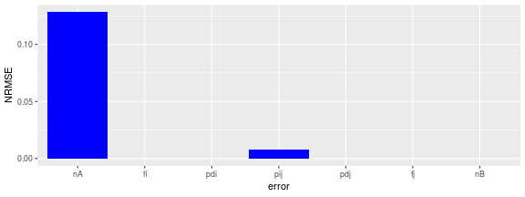

```r
plot_errors(solved)
```

We can plot the population sizes to confirm that:

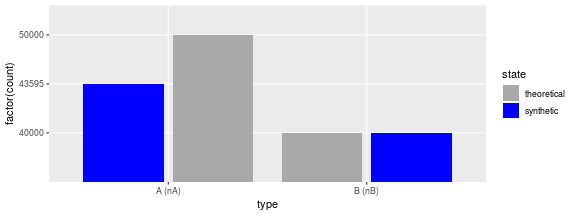

```r
plot_population_sizes(solved)
```

We also can investigate what happend to pairing probabilities.

```r
# input probabilities
solved$inputs$pij
```

```
#> matching probabilities given 'surface' and 'size':
#>        surface=1 surface=2 surface=3
#> size=1     0.200    0.0375    0.0125
#> size=2     0.100    0.1250    0.0250
#> size=3     0.050    0.1000    0.1000
#> size=4     0.025    0.0500    0.1750
```

```r
# solved probabilities
solved$gen$hat.pij
```

```
#>        surface=1 surface=2 surface=3
#> size=1  0.219725  0.041200  0.013725
#> size=2  0.089275  0.111600  0.022325
#> size=3  0.052075  0.104125  0.104150
#> size=4  0.024175  0.048375  0.169250
```

```r
# display the measure of differences: positive values are probabilities in excess.
errors.pij(solved)
```

```
#>        surface=1 surface=2 surface=3
#> size=1  0.019725  0.003700  0.001225
#> size=2 -0.010725 -0.013400 -0.002675
#> size=3  0.002075  0.004125  0.004150
#> size=4 -0.000825 -0.001625 -0.005750
```

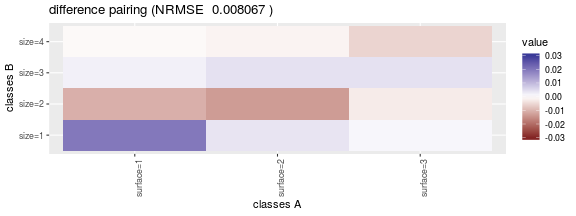

```r
# we also can plot that as an heatmap. Red means "not enough created", blue "too many".
# the differences are so low they are not very visible here.
plot_errors_pij(solved)
```

### Resolution and relaxation of parameters

Let's now imagine we would like to keep the count of entities A (dwellings), the relative frequencies for A, and the degree of connectivity. It means we are sure of these parameters, and accept to report errors on other characteristics.

```r
solved <- matching.solve(
                      prepared, nA=50000, nB=40000, nu.A=0, phi.A=0,
                      delta.A=0, gamma=0, delta.B=1, phi.B=1, nu.B=1, verbose=TRUE)
```

```
#>
#> starting the resolution of the case
#>  according to user weights, we already know: hat.nA,hat.fi,hat.di,hat.pdi,hat.pij
#>  checking the consistency of the current solution with hat.nA, hat.fi, hat.di, hat.pij
#>  => the solution is consistent
#>  solving equations based on known variables: hat.nA, hat.fi, hat.di, hat.pij
#>      hat.nA, hat.fi -> hat.ci
#>      hat.ci, hat.di -> hat.ni [hat.pi]
#>      hat.ni -> hat.nL
#>      hat.ni, hat.pij -> hat.nij [hat.pij]
#>      hat.nij -> hat.nj
#>      hat.pij -> hat.pj
#>      hat.pdi, hat.ci, hat.ni -> hat.ndi
#>  checking the consistency of the current solution with hat.nA, hat.fi, hat.di, hat.pij, hat.ci
#>  => the solution is consistent
#>      trying with hypothesis: hat.nA=nA
#>          solving equations based on known variables: hat.nA, hat.fi, hat.di, hat.pij, hat.ci
#>          these hypothesis do not enable the resolution of all the required variables.
#>      trying with hypothesis: hat.fi=fi
#>          solving equations based on known variables: hat.nA, hat.fi, hat.di, hat.pij, hat.ci
#>          these hypothesis do not enable the resolution of all the required variables.
#>      trying with hypothesis: hat.di=di
#>          solving equations based on known variables: hat.nA, hat.fi, hat.di, hat.pij, hat.ci
#>          these hypothesis do not enable the resolution of all the required variables.
#>      trying with hypothesis: hat.pij=pij
#>          solving equations based on known variables: hat.nA, hat.fi, hat.di, hat.pij, hat.ci
#>          these hypothesis do not enable the resolution of all the required variables.
#>      trying with hypothesis: hat.dj=dj
#>          solving equations based on known variables: hat.nA, hat.fi, hat.di, hat.pij, hat.ci, hat.dj
#>              hat.nj, hat.dj -> hat.cj
#>              hat.cj -> hat.fj
#>              hat.dj -> hat.pdj
#>              hat.cj -> hat.nB
#>              hat.pdj, hat.cj, hat.nj -> hat.ndj
#>          checking the consistency of the current solution with hat.nA, hat.fi, hat.di, hat.pij, hat.ci, hat.dj, hat.cj, hat.fj, hat.nB
#>          => the solution is consistent
#>          we found a valid solution which provides:  hat.nA, hat.fi, hat.di, hat.pij, hat.ci, hat.dj, hat.cj, hat.fj, hat.nB
#> Warning in chisq.test(x, B = y): Chi-squared approximation may be incorrect
```

```
#> Warning in chisq.test(x, B = y): Chi-squared approximation may be incorrect
#>          here are the NRMSE errors of this solution: nA=0, fi=0, di=0, pij=0.02238, dj=0, fj=0.04324, nB=0.1835
#>      trying with hypothesis: hat.di=di,hat.nB=nB
#>          solving equations based on known variables: hat.nA, hat.fi, hat.di, hat.pij, hat.ci, hat.nB
#>          these hypothesis do not enable the resolution of all the required variables.
#>      trying with hypothesis: hat.pij=pij,hat.dj=dj
#>          solving equations based on known variables: hat.nA, hat.fi, hat.di, hat.pij, hat.ci, hat.dj
#>              hat.nj, hat.dj -> hat.cj
#>              hat.cj -> hat.fj
#>              hat.dj -> hat.pdj
#>              hat.cj -> hat.nB
#>              hat.pdj, hat.cj, hat.nj -> hat.ndj
#>          checking the consistency of the current solution with hat.nA, hat.fi, hat.di, hat.pij, hat.ci, hat.dj, hat.cj, hat.fj, hat.nB
#>              assert error on 'hat.pij = hat.nij/sum(hat.nij)'
#>              Modes: numeric, listLengths: 12, 3names for current but not for targetAttributes: < Names: 2 string mismatches >Attributes: < Component 1: Modes: numeric, character >Attributes: < Component 1: Lengths: 2, 1 >Attributes: < Component 1: target is numeric, current is character >Attribut…
#>              assert error on 'hat.pi = colSums(hat.pij)': 0.375,0.3125,0.3125 != 0.278845747602349,0.333664286619629,0.387489965778022
#>              assert error on 'hat.pj = rowSums(hat.pij)': 0.25,0.25,0.25,0.25 != 0.204275634796569,0.238814483079133,0.267945413832439,0.288964468291859
#>          => the solution is NOT consistent: 3 problems detected
#>          we found an invalid solution (3 inconsistencies found)
#>      trying with hypothesis: hat.pij=pij,hat.fj=fj
#>          solving equations based on known variables: hat.nA, hat.fi, hat.di, hat.pij, hat.ci, hat.fj
#>              hat.pj, hat.fj -> hat.dj [hat.fj]
#>              hat.dj -> hat.pdj
#>              hat.nj, hat.dj -> hat.cj
#>              hat.pdj, hat.cj, hat.nj -> hat.ndj
#>              hat.cj -> hat.nB
#>          checking the consistency of the current solution with hat.nA, hat.fi, hat.di, hat.pij, hat.ci, hat.fj, hat.dj, hat.cj, hat.nB
#>              assert error on 'hat.pij = hat.nij/sum(hat.nij)'
#>              Modes: numeric, listLengths: 12, 3names for current but not for targetAttributes: < Names: 2 string mismatches >Attributes: < Component 1: Modes: numeric, character >Attributes: < Component 1: Lengths: 2, 1 >Attributes: < Component 1: target is numeric, current is character >Attribut…
#>              assert error on 'hat.pi = colSums(hat.pij)': 0.375,0.3125,0.3125 != 0.278845747602349,0.333664286619629,0.387489965778022
#>              assert error on 'hat.pj = rowSums(hat.pij)': 0.25,0.25,0.25,0.25 != 0.204275634796569,0.238814483079133,0.267945413832439,0.288964468291859
#>          => the solution is NOT consistent: 3 problems detected
#>          we found an invalid solution (3 inconsistencies found)
#>      trying with hypothesis: hat.pij=pij,hat.nB=nB
#>          solving equations based on known variables: hat.nA, hat.fi, hat.di, hat.pij, hat.ci, hat.nB
#>          these hypothesis do not enable the resolution of all the required variables.
#>      trying with hypothesis: hat.dj=dj,hat.fj=fj
#>          solving equations based on known variables: hat.nA, hat.fi, hat.di, hat.pij, hat.ci, hat.dj, hat.fj
#>              hat.nj, hat.dj -> hat.cj
#>              hat.dj -> hat.pdj
#>              hat.cj -> hat.nB
#>              hat.pdj, hat.cj, hat.nj -> hat.ndj
#>          checking the consistency of the current solution with hat.nA, hat.fi, hat.di, hat.pij, hat.ci, hat.dj, hat.fj, hat.cj, hat.nB
#>          => the solution is consistent
#>          we found a valid solution which provides:  hat.nA, hat.fi, hat.di, hat.pij, hat.ci, hat.dj, hat.fj, hat.cj, hat.nB
#> Warning in chisq.test(x, B = y): Chi-squared approximation may be incorrect
```

```
#> Warning in chisq.test(x, B = y): Chi-squared approximation may be incorrect
#>          here are the NRMSE errors of this solution: nA=0, fi=0, di=1.574E-05, pij=0.02238, dj=0, fj=0, nB=0.1835
#>      trying with hypothesis: hat.dj=dj,hat.nB=nB
#>          solving equations based on known variables: hat.nA, hat.fi, hat.di, hat.pij, hat.ci, hat.dj, hat.nB
#>              hat.nj, hat.dj -> hat.cj
#>              hat.cj -> hat.fj
#>              hat.dj -> hat.pdj
#>              hat.pdj, hat.cj, hat.nj -> hat.ndj
#>          checking the consistency of the current solution with hat.nA, hat.fi, hat.di, hat.pij, hat.ci, hat.dj, hat.nB, hat.cj, hat.fj
#>              assert error on 'hat.nB = sum(hat.cj)': 40000 != 47338
#>          => the solution is NOT consistent: 1 problems detected
#>          we found an invalid solution (1 inconsistencies found)
#>      trying with hypothesis: hat.fj=fj,hat.nB=nB
#>          solving equations based on known variables: hat.nA, hat.fi, hat.di, hat.pij, hat.ci, hat.fj, hat.nB
#>              hat.nB, hat.fj -> hat.cj
#>              hat.nj, hat.cj -> hat.dj
#>              hat.dj -> hat.pdj
#>              hat.pdj, hat.cj, hat.nj -> hat.ndj
#>          found an invalid solution (inference failed: Error in rectify.degree.counts(sol$hat.ndj, sol$hat.nj, sol$hat.cj, verbose = F): was unable to fix the rounding of degree distributions so the total slots 9670,8928,10414,9672 sums up to 9670,11305,12684,13679
#> )
#>      trying with hypothesis: hat.nA=nA,hat.fi=fi,hat.di=di
#>          solving equations based on known variables: hat.nA, hat.fi, hat.di, hat.pij, hat.ci
#>          these hypothesis do not enable the resolution of all the required variables.
#>      trying with hypothesis: hat.nA=nA,hat.fi=fi,hat.pij=pij
#>          solving equations based on known variables: hat.nA, hat.fi, hat.di, hat.pij, hat.ci
#>          these hypothesis do not enable the resolution of all the required variables.
#>      trying with hypothesis: hat.nA=nA,hat.fi=fi,hat.dj=dj
#>          solving equations based on known variables: hat.nA, hat.fi, hat.di, hat.pij, hat.ci, hat.dj
#>              hat.nj, hat.dj -> hat.cj
#>              hat.cj -> hat.fj
#>              hat.dj -> hat.pdj
#>              hat.cj -> hat.nB
#>              hat.pdj, hat.cj, hat.nj -> hat.ndj
#>          checking the consistency of the current solution with hat.nA, hat.fi, hat.di, hat.pij, hat.ci, hat.dj, hat.cj, hat.fj, hat.nB
#>          => the solution is consistent
#>          we found a valid solution which provides:  hat.nA, hat.fi, hat.di, hat.pij, hat.ci, hat.dj, hat.cj, hat.fj, hat.nB
#> Warning in chisq.test(x, B = y): Chi-squared approximation may be incorrect
```

```
#> Warning in chisq.test(x, B = y): Chi-squared approximation may be incorrect
#>          here are the NRMSE errors of this solution: nA=0, fi=0, di=0, pij=0.02238, dj=0, fj=0, nB=0.1835
#>      skipping hat.nA=nA,hat.fi=fi,hat.di=di,hat.dj=dj,hat.nB=nB because hat.dj=dj,hat.nB=nBfailed in the past
#>      skipping hat.nA=nA,hat.fi=fi,hat.di=di,hat.fj=fj,hat.nB=nB because hat.fj=fj,hat.nB=nBfailed in the past
#>      skipping hat.nA=nA,hat.fi=fi,hat.pij=pij,hat.dj=dj,hat.fj=fj because hat.pij=pij,hat.dj=djfailed in the past
#>      skipping hat.nA=nA,hat.fi=fi,hat.pij=pij,hat.dj=dj,hat.nB=nB because hat.pij=pij,hat.dj=djfailed in the past
#>      skipping hat.nA=nA,hat.fi=fi,hat.pij=pij,hat.fj=fj,hat.nB=nB because hat.pij=pij,hat.fj=fjfailed in the past
#>      skipping hat.nA=nA,hat.fi=fi,hat.dj=dj,hat.fj=fj,hat.nB=nB because hat.dj=dj,hat.nB=nBfailed in the past
#>      skipping hat.nA=nA,hat.di=di,hat.pij=pij,hat.dj=dj,hat.fj=fj because hat.pij=pij,hat.dj=djfailed in the past
#>      skipping hat.nA=nA,hat.di=di,hat.pij=pij,hat.dj=dj,hat.nB=nB because hat.pij=pij,hat.dj=djfailed in the past
#>      skipping hat.nA=nA,hat.di=di,hat.pij=pij,hat.fj=fj,hat.nB=nB because hat.pij=pij,hat.fj=fjfailed in the past
#>      skipping hat.nA=nA,hat.di=di,hat.dj=dj,hat.fj=fj,hat.nB=nB because hat.dj=dj,hat.nB=nBfailed in the past
#>      skipping hat.nA=nA,hat.pij=pij,hat.dj=dj,hat.fj=fj,hat.nB=nB because hat.pij=pij,hat.dj=djfailed in the past
#>      skipping hat.fi=fi,hat.di=di,hat.pij=pij,hat.dj=dj,hat.fj=fj because hat.pij=pij,hat.dj=djfailed in the past
#>      skipping hat.fi=fi,hat.di=di,hat.pij=pij,hat.dj=dj,hat.nB=nB because hat.pij=pij,hat.dj=djfailed in the past
#>      skipping hat.fi=fi,hat.di=di,hat.pij=pij,hat.fj=fj,hat.nB=nB because hat.pij=pij,hat.fj=fjfailed in the past
#>      skipping hat.fi=fi,hat.di=di,hat.dj=dj,hat.fj=fj,hat.nB=nB because hat.dj=dj,hat.nB=nBfailed in the past
#>      skipping hat.fi=fi,hat.pij=pij,hat.dj=dj,hat.fj=fj,hat.nB=nB because hat.pij=pij,hat.dj=djfailed in the past
#>      skipping hat.di=di,hat.pij=pij,hat.dj=dj,hat.fj=fj,hat.nB=nB because hat.pij=pij,hat.dj=djfailed in the past
#>      skipping hat.nA=nA,hat.fi=fi,hat.di=di,hat.pij=pij,hat.dj=dj,hat.fj=fj because hat.pij=pij,hat.dj=djfailed in the past
#>      skipping hat.nA=nA,hat.fi=fi,hat.di=di,hat.pij=pij,hat.dj=dj,hat.nB=nB because hat.pij=pij,hat.dj=djfailed in the past
#>      skipping hat.nA=nA,hat.fi=fi,hat.di=di,hat.pij=pij,hat.fj=fj,hat.nB=nB because hat.pij=pij,hat.fj=fjfailed in the past
#>      skipping hat.nA=nA,hat.fi=fi,hat.di=di,hat.dj=dj,hat.fj=fj,hat.nB=nB because hat.dj=dj,hat.nB=nBfailed in the past
#>      skipping hat.nA=nA,hat.fi=fi,hat.pij=pij,hat.dj=dj,hat.fj=fj,hat.nB=nB because hat.pij=pij,hat.dj=djfailed in the past
#>      skipping hat.nA=nA,hat.di=di,hat.pij=pij,hat.dj=dj,hat.fj=fj,hat.nB=nB because hat.pij=pij,hat.dj=djfailed in the past
#>      skipping hat.fi=fi,hat.di=di,hat.pij=pij,hat.dj=dj,hat.fj=fj,hat.nB=nB because hat.pij=pij,hat.dj=djfailed in the past
#>      skipping hat.nA=nA,hat.fi=fi,hat.di=di,hat.pij=pij,hat.dj=dj,hat.fj=fj,hat.nB=nB because hat.pij=pij,hat.dj=djfailed in the past
#>      found  24  solutions, we have to select the best according to weights nu.A=0, phi.A=0, delta.A=0, gamma=0, delta.B=1, phi.B=1, nu.B=1
#>          solution (1) (224.3) => hat.dj=dj
#>               errors:     RNMSE.nA=0, RNMSE.fi=0, RNMSE.pdi=2.679E-05, RNMSE.pij=0.02238, RNMSE.pdj=0, RNMSE.fj=0.04324, RNMSE.nB=0.1835
#>          solution (2) (224.3) => hat.fj=fj
#>               errors:     RNMSE.nA=0, RNMSE.fi=0, RNMSE.pdi=2.679E-05, RNMSE.pij=0.02238, RNMSE.pdj=0, RNMSE.fj=0.04324, RNMSE.nB=0.1835
#>          solution (3) (224.3) => hat.nA=nA,hat.dj=dj
#>               errors:     RNMSE.nA=0, RNMSE.fi=0, RNMSE.pdi=2.679E-05, RNMSE.pij=0.02238, RNMSE.pdj=0, RNMSE.fj=0.04324, RNMSE.nB=0.1835
#>          solution (4) (224.3) => hat.nA=nA,hat.fj=fj
#>               errors:     RNMSE.nA=0, RNMSE.fi=0, RNMSE.pdi=2.679E-05, RNMSE.pij=0.02238, RNMSE.pdj=0, RNMSE.fj=0.04324, RNMSE.nB=0.1835
#>          solution (5) (224.3) => hat.fi=fi,hat.dj=dj
#>               errors:     RNMSE.nA=0, RNMSE.fi=0, RNMSE.pdi=2.679E-05, RNMSE.pij=0.02238, RNMSE.pdj=0, RNMSE.fj=0.04324, RNMSE.nB=0.1835
#>          solution (6) (224.3) => hat.fi=fi,hat.fj=fj
#>               errors:     RNMSE.nA=0, RNMSE.fi=0, RNMSE.pdi=2.679E-05, RNMSE.pij=0.02238, RNMSE.pdj=0, RNMSE.fj=0.04324, RNMSE.nB=0.1835
```

[output cut: 37 more lines]

```
#>              * solution 9 solved with:   hat.dj=dj,hat.fj=fj
#>              * solution 14 solved with:  hat.nA=nA,hat.dj=dj,hat.fj=fj
#>              * solution 17 solved with:  hat.fi=fi,hat.dj=dj,hat.fj=fj
#>              * solution 18 solved with:  hat.di=di,hat.dj=dj,hat.fj=fj
#>              * solution 21 solved with:  hat.nA=nA,hat.fi=fi,hat.dj=dj,hat.fj=fj
#>              * solution 22 solved with:  hat.nA=nA,hat.di=di,hat.dj=dj,hat.fj=fj
#>              * solution 23 solved with:  hat.fi=fi,hat.di=di,hat.dj=dj,hat.fj=fj
#>              * solution 24 solved with:  hat.nA=nA,hat.fi=fi,hat.di=di,hat.dj=dj,hat.fj=fj
#>      => randomly selected 23 which is one of the 8 solutions having lowest weighted error
#>          this solution is based on hypothesis: hat.fi=fi,hat.di=di,hat.dj=dj,hat.fj=fj
#>  checking the consistency of the current solution with hat.nA, hat.fi, hat.di, hat.pij, hat.ci, hat.dj, hat.fj, hat.cj, hat.nB
#>  => the solution is consistent
#>
#> case solved.
#> Warning in chisq.test(x, B = y): Chi-squared approximation may be incorrect
```

We displayed the resolution process in order to show how it works. Basically, every relaxation parameter set to 0 means the initial value is taken for granted. Then equations are applied in order to compute values for other variables. If the solving leads to contradictions between values, it means the problem is overconstrained. Most of the time, you don't need to care about this level of detail.

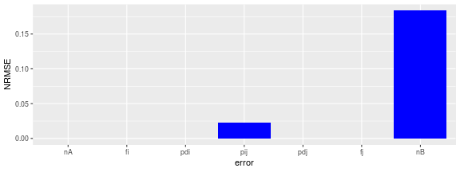

```r
plot_errors(solved)
```

The plot of errors shows how the algorithm, following our request, reported the errors elsewhere (here in pairing probabilities and count of households).

Let's now try to enforce pairing probabilities by setting relaxation parameter \(\gamma=0\):

```r
solved <- matching.solve(
                      prepared, nA=50000, nB=40000, nu.A=1, phi.A=1,
                      delta.A=1, gamma=0, delta.B=1, phi.B=1, nu.B=1, verbose=TRUE)
```

```
#>
#> starting the resolution of the case
#>  according to user weights, we already know: hat.pij
#>  checking the consistency of the current solution with hat.pij
#>  => the solution is consistent
#>  solving equations based on known variables: hat.pij
#>      hat.pij -> hat.pi
#>      hat.pij -> hat.pj
#>  checking the consistency of the current solution with hat.pij
#>  => the solution is consistent
#>      trying with hypothesis: hat.nA=nA
#>          solving equations based on known variables: hat.pij, hat.nA
#>          these hypothesis do not enable the resolution of all the required variables.
#>      trying with hypothesis: hat.fi=fi
#>          solving equations based on known variables: hat.pij, hat.fi
#>              hat.pi, hat.fi -> hat.di [hat.fi]
#>              hat.di -> hat.pdi
#>          these hypothesis do not enable the resolution of all the required variables.
#>      trying with hypothesis: hat.di=di
#>          solving equations based on known variables: hat.pij, hat.di
#>              hat.di -> hat.pdi
#>          these hypothesis do not enable the resolution of all the required variables.
#>      trying with hypothesis: hat.pij=pij
#>          solving equations based on known variables: hat.pij
#>          these hypothesis do not enable the resolution of all the required variables.
#>      trying with hypothesis: hat.dj=dj
#>          solving equations based on known variables: hat.pij, hat.dj
#>              hat.dj -> hat.pdj
#>          these hypothesis do not enable the resolution of all the required variables.
#>      trying with hypothesis: hat.fj=fj
#>          solving equations based on known variables: hat.pij, hat.fj
#>              hat.pj, hat.fj -> hat.dj [hat.fj]
#>              hat.dj -> hat.pdj
#>          these hypothesis do not enable the resolution of all the required variables.
#>      trying with hypothesis: hat.nB=nB
#>          solving equations based on known variables: hat.pij, hat.nB
#>          these hypothesis do not enable the resolution of all the required variables.
#>      trying with hypothesis: hat.nA=nA,hat.fi=fi
#>          solving equations based on known variables: hat.pij, hat.nA, hat.fi
#>              hat.nA, hat.fi -> hat.ci
```

[output cut: 129 more lines]

```
#>              hat.di -> hat.pdi
#>              hat.dj -> hat.pdj
#>              hat.ci, hat.di -> hat.ni [hat.pi]
#>              hat.ni -> hat.nL
#>              hat.ni, hat.pij -> hat.nij [hat.pij]
#>              hat.nij -> hat.nj [hat.pj]
#>              hat.nj, hat.dj -> hat.cj
#>              hat.cj -> hat.fj
#>              hat.pdi, hat.ci, hat.ni -> hat.ndi
#>              hat.pdj, hat.cj, hat.nj -> hat.ndj
#>              hat.cj -> hat.nB
#>          checking the consistency of the current solution with hat.pij, hat.nA, hat.fi, hat.dj, hat.ci, hat.di, hat.cj, hat.fj, hat.nB
#>          => the solution is consistent
#>          we found a valid solution which provides:  hat.pij, hat.nA, hat.fi, hat.dj, hat.ci, hat.di, hat.cj, hat.fj, hat.nB
#> Warning in chisq.test(x, B = y): Chi-squared approximation may be incorrect
```

```
#> Warning in chisq.test(x, B = y): Chi-squared approximation may be incorrect
#>          here are the NRMSE errors of this solution: nA=0, fi=0.02041, di=0.132, pij=0.006358, dj=0, fj=0.01936, nB=0.1938
#>      trying with hypothesis: hat.nA=nA,hat.fi=fi,hat.nB=nB
#>          solving equations based on known variables: hat.pij, hat.nA, hat.fi, hat.nB
#>              hat.nA, hat.fi -> hat.ci
#>              hat.pi, hat.fi -> hat.di [hat.fi]
#>              hat.di -> hat.pdi
#>              hat.ci, hat.di -> hat.ni [hat.pi]
#>              hat.ni -> hat.nL
#>              hat.ni, hat.pij -> hat.nij [hat.pij]
#>              hat.nij -> hat.nj [hat.pj]
#>              hat.pdi, hat.ci, hat.ni -> hat.ndi
#>          these hypothesis do not enable the resolution of all the required variables.
#>      trying with hypothesis: hat.nA=nA,hat.di=di,hat.pij=pij
#>          solving equations based on known variables: hat.pij, hat.nA, hat.di
#>              hat.di -> hat.pdi
#>          these hypothesis do not enable the resolution of all the required variables.
#>      trying with hypothesis: hat.nA=nA,hat.di=di,hat.dj=dj
#>          solving equations based on known variables: hat.pij, hat.nA, hat.di, hat.dj
#>              hat.di -> hat.pdi
#>              hat.dj -> hat.pdj
#>          these hypothesis do not enable the resolution of all the required variables.
#>      trying with hypothesis: hat.nA=nA,hat.di=di,hat.fj=fj
#>          solving equations based on known variables: hat.pij, hat.nA, hat.di, hat.fj
#>              hat.pj, hat.fj -> hat.dj [hat.fj]
#>              hat.di -> hat.pdi
#>              hat.dj -> hat.pdj
#>          these hypothesis do not enable the resolution of all the required variables.
#>      trying with hypothesis: hat.nA=nA,hat.di=di,hat.nB=nB
#>          solving equations based on known variables: hat.pij, hat.nA, hat.di, hat.nB
#>              hat.di -> hat.pdi
#>          these hypothesis do not enable the resolution of all the required variables.
#>      trying with hypothesis: hat.nA=nA,hat.pij=pij,hat.dj=dj
#>          solving equations based on known variables: hat.pij, hat.nA, hat.dj
#>              hat.dj -> hat.pdj
#>          these hypothesis do not enable the resolution of all the required variables.
#>      trying with hypothesis: hat.nA=nA,hat.pij=pij,hat.fj=fj
#>          solving equations based on known variables: hat.pij, hat.nA, hat.fj
#>              hat.pj, hat.fj -> hat.dj [hat.fj]
#>              hat.dj -> hat.pdj
```

[output cut: 76 more lines]

```
#>              hat.pj, hat.fj -> hat.dj [hat.fj]
#>              hat.di -> hat.pdi
#>              hat.dj -> hat.pdj
#>              hat.cj, hat.dj -> hat.nj [hat.pj]
#>              hat.nj -> hat.nL
#>              hat.nj, hat.pij -> hat.nij [hat.pij]
#>              hat.nij -> hat.ni [hat.pi]
#>              hat.ni, hat.di -> hat.ci
#>              hat.pdi, hat.ci, hat.ni -> hat.ndi
#>              hat.pdj, hat.cj, hat.nj -> hat.ndj
#>              hat.ci -> hat.nA
#>          checking the consistency of the current solution with hat.pij, hat.fi, hat.fj, hat.nB, hat.cj, hat.di, hat.dj, hat.ci, hat.nA
#>          => the solution is consistent
#>          we found a valid solution which provides:  hat.pij, hat.fi, hat.fj, hat.nB, hat.cj, hat.di, hat.dj, hat.ci, hat.nA
#> Warning in chisq.test(x, B = y): Chi-squared approximation may be incorrect
```

```
#> Warning in chisq.test(x, B = y): Chi-squared approximation may be incorrect
#>          here are the NRMSE errors of this solution: nA=0.1648, fi=0.02041, di=0.132, pij=0.008067, dj=0, fj=0.01936, nB=0
#>      trying with hypothesis: hat.di=di,hat.pij=pij,hat.dj=dj
#>          solving equations based on known variables: hat.pij, hat.di, hat.dj
#>              hat.di -> hat.pdi
#>              hat.dj -> hat.pdj
#>          these hypothesis do not enable the resolution of all the required variables.
#>      trying with hypothesis: hat.di=di,hat.pij=pij,hat.fj=fj
#>          solving equations based on known variables: hat.pij, hat.di, hat.fj
#>              hat.pj, hat.fj -> hat.dj [hat.fj]
#>              hat.di -> hat.pdi
#>              hat.dj -> hat.pdj
#>          these hypothesis do not enable the resolution of all the required variables.
#>      trying with hypothesis: hat.di=di,hat.pij=pij,hat.nB=nB
#>          solving equations based on known variables: hat.pij, hat.di, hat.nB
#>              hat.di -> hat.pdi
#>          these hypothesis do not enable the resolution of all the required variables.
#>      trying with hypothesis: hat.di=di,hat.dj=dj,hat.fj=fj
#>          solving equations based on known variables: hat.pij, hat.di, hat.dj, hat.fj
#>              hat.di -> hat.pdi
#>              hat.dj -> hat.pdj
#>          these hypothesis do not enable the resolution of all the required variables.
#>      trying with hypothesis: hat.di=di,hat.dj=dj,hat.nB=nB
#>          solving equations based on known variables: hat.pij, hat.di, hat.dj, hat.nB
#>              hat.di -> hat.pdi
#>              hat.dj -> hat.pdj
#>          these hypothesis do not enable the resolution of all the required variables.
#>      trying with hypothesis: hat.di=di,hat.fj=fj,hat.nB=nB
#>          solving equations based on known variables: hat.pij, hat.di, hat.fj, hat.nB
#>              hat.nB, hat.fj -> hat.cj
#>              hat.pj, hat.fj -> hat.dj [hat.fj]
#>              hat.di -> hat.pdi
#>              hat.dj -> hat.pdj
#>              hat.cj, hat.dj -> hat.nj [hat.pj]
#>              hat.nj -> hat.nL
#>              hat.nj, hat.pij -> hat.nij [hat.pij]
#>              hat.nij -> hat.ni [hat.pi]
#>              hat.ni, hat.di -> hat.ci
#>              hat.ci -> hat.fi
#>              hat.pdi, hat.ci, hat.ni -> hat.ndi
#>              hat.pdj, hat.cj, hat.nj -> hat.ndj
#>              hat.ci -> hat.nA
#>          checking the consistency of the current solution with hat.pij, hat.di, hat.fj, hat.nB, hat.cj, hat.dj, hat.ci, hat.fi, hat.nA
#>          => the solution is consistent
#>          we found a valid solution which provides:  hat.pij, hat.di, hat.fj, hat.nB, hat.cj, hat.dj, hat.ci, hat.fi, hat.nA
#> Warning in chisq.test(x, B = y): Chi-squared approximation may be incorrect
```

```
#> Warning in chisq.test(x, B = y): Chi-squared approximation may be incorrect
#>          here are the NRMSE errors of this solution: nA=0.1281, fi=0.08019, di=2.794E-05, pij=0.008067, dj=0, fj=0.01936, nB=0
#>      trying with hypothesis: hat.pij=pij,hat.dj=dj,hat.fj=fj
#>          solving equations based on known variables: hat.pij, hat.dj, hat.fj
#>              hat.dj -> hat.pdj
#>          these hypothesis do not enable the resolution of all the required variables.
#>      trying with hypothesis: hat.pij=pij,hat.dj=dj,hat.nB=nB
#>          solving equations based on known variables: hat.pij, hat.dj, hat.nB
#>              hat.dj -> hat.pdj
#>          these hypothesis do not enable the resolution of all the required variables.
#>      trying with hypothesis: hat.pij=pij,hat.fj=fj,hat.nB=nB
#>          solving equations based on known variables: hat.pij, hat.fj, hat.nB
#>              hat.nB, hat.fj -> hat.cj
#>              hat.pj, hat.fj -> hat.dj [hat.fj]
#>              hat.dj -> hat.pdj
#>              hat.cj, hat.dj -> hat.nj [hat.pj]
#>              hat.nj -> hat.nL
#>              hat.nj, hat.pij -> hat.nij [hat.pij]
#>              hat.nij -> hat.ni [hat.pi]
#>              hat.pdj, hat.cj, hat.nj -> hat.ndj
#>          these hypothesis do not enable the resolution of all the required variables.
#>      trying with hypothesis: hat.dj=dj,hat.fj=fj,hat.nB=nB
#>          solving equations based on known variables: hat.pij, hat.dj, hat.fj, hat.nB
#>              hat.nB, hat.fj -> hat.cj
#>              hat.cj, hat.dj -> hat.nj [hat.pj]
#>              hat.nj -> hat.nL
#>              hat.nj, hat.pij -> hat.nij [hat.pij]
#>              hat.nij -> hat.ni [hat.pi]
#>              hat.dj -> hat.pdj
#>              hat.pdj, hat.cj, hat.nj -> hat.ndj
#>          these hypothesis do not enable the resolution of all the required variables.
#>      trying with hypothesis: hat.nA=nA,hat.fi=fi,hat.di=di,hat.pij=pij
#>          solving equations based on known variables: hat.pij, hat.nA, hat.fi, hat.di
#>              hat.nA, hat.fi -> hat.ci
#>              hat.ci, hat.di -> hat.ni [hat.pi]
#>              hat.ni -> hat.nL
#>              hat.ni, hat.pij -> hat.nij [hat.pij]
#>              hat.nij -> hat.nj [hat.pj]
#>              hat.di -> hat.pdi
#>              hat.pdi, hat.ci, hat.ni -> hat.ndi
#>          these hypothesis do not enable the resolution of all the required variables.
#>      trying with hypothesis: hat.nA=nA,hat.fi=fi,hat.di=di,hat.dj=dj
#>          solving equations based on known variables: hat.pij, hat.nA, hat.fi, hat.di, hat.dj
#>              hat.nA, hat.fi -> hat.ci
#>              hat.ci, hat.di -> hat.ni [hat.pi]
#>              hat.ni -> hat.nL
#>              hat.ni, hat.pij -> hat.nij [hat.pij]
#>              hat.nij -> hat.nj [hat.pj]
#>              hat.nj, hat.dj -> hat.cj
#>              hat.cj -> hat.fj
#>              hat.di -> hat.pdi
#>              hat.dj -> hat.pdj
#>              hat.cj -> hat.nB
#>              hat.pdi, hat.ci, hat.ni -> hat.ndi
#>              hat.pdj, hat.cj, hat.nj -> hat.ndj
#>          checking the consistency of the current solution with hat.pij, hat.nA, hat.fi, hat.di, hat.dj, hat.ci, hat.cj, hat.fj, hat.nB
#>          => the solution is consistent
#>          we found a valid solution which provides:  hat.pij, hat.nA, hat.fi, hat.di, hat.dj, hat.ci, hat.cj, hat.fj, hat.nB
#> Warning in chisq.test(x, B = y): Chi-squared approximation may be incorrect
```

```
#> Warning in chisq.test(x, B = y): Chi-squared approximation may be incorrect
#>          here are the NRMSE errors of this solution: nA=0, fi=0, di=1.574E-05, pij=0.02238, dj=0, fj=0.04324, nB=0.1835
#>      trying with hypothesis: hat.nA=nA,hat.fi=fi,hat.di=di,hat.nB=nB
#>          solving equations based on known variables: hat.pij, hat.nA, hat.fi, hat.di, hat.nB
#>              hat.nA, hat.fi -> hat.ci
#>              hat.ci, hat.di -> hat.ni [hat.pi]
#>              hat.ni -> hat.nL
#>              hat.ni, hat.pij -> hat.nij [hat.pij]
#>              hat.nij -> hat.nj [hat.pj]
#>              hat.di -> hat.pdi
#>              hat.pdi, hat.ci, hat.ni -> hat.ndi
#>          these hypothesis do not enable the resolution of all the required variables.
#>      trying with hypothesis: hat.nA=nA,hat.fi=fi,hat.pij=pij,hat.dj=dj
#>          solving equations based on known variables: hat.pij, hat.nA, hat.fi, hat.dj
#>              hat.nA, hat.fi -> hat.ci
#>              hat.pi, hat.fi -> hat.di [hat.fi]
#>              hat.di -> hat.pdi
#>              hat.dj -> hat.pdj
#>              hat.ci, hat.di -> hat.ni [hat.pi]
#>              hat.ni -> hat.nL
#>              hat.ni, hat.pij -> hat.nij [hat.pij]
#>              hat.nij -> hat.nj [hat.pj]
#>              hat.nj, hat.dj -> hat.cj
#>              hat.cj -> hat.fj
#>              hat.pdi, hat.ci, hat.ni -> hat.ndi
#>              hat.pdj, hat.cj, hat.nj -> hat.ndj
#>              hat.cj -> hat.nB
#>          checking the consistency of the current solution with hat.pij, hat.nA, hat.fi, hat.dj, hat.ci, hat.di, hat.cj, hat.fj, hat.nB
#>          => the solution is consistent
#>          we found a valid solution which provides:  hat.pij, hat.nA, hat.fi, hat.dj, hat.ci, hat.di, hat.cj, hat.fj, hat.nB
#> Warning in chisq.test(x, B = y): Chi-squared approximation may be incorrect
```

```
#> Warning in chisq.test(x, B = y): Chi-squared approximation may be incorrect
#>          here are the NRMSE errors of this solution: nA=0, fi=0.02041, di=0.132, pij=0.006358, dj=0, fj=0.01936, nB=0.1938
#>      trying with hypothesis: hat.nA=nA,hat.fi=fi,hat.pij=pij,hat.nB=nB
#>          solving equations based on known variables: hat.pij, hat.nA, hat.fi, hat.nB
#>              hat.nA, hat.fi -> hat.ci
#>              hat.pi, hat.fi -> hat.di [hat.fi]
#>              hat.di -> hat.pdi
#>              hat.ci, hat.di -> hat.ni [hat.pi]
#>              hat.ni -> hat.nL
#>              hat.ni, hat.pij -> hat.nij [hat.pij]
#>              hat.nij -> hat.nj [hat.pj]
#>              hat.pdi, hat.ci, hat.ni -> hat.ndi
#>          these hypothesis do not enable the resolution of all the required variables.
#>      trying with hypothesis: hat.nA=nA,hat.fi=fi,hat.dj=dj,hat.fj=fj
#>          solving equations based on known variables: hat.pij, hat.nA, hat.fi, hat.dj, hat.fj
#>              hat.nA, hat.fi -> hat.ci
#>              hat.pi, hat.fi -> hat.di [hat.fi]
#>              hat.di -> hat.pdi
#>              hat.dj -> hat.pdj
#>              hat.ci, hat.di -> hat.ni [hat.pi]
#>              hat.ni -> hat.nL
#>              hat.ni, hat.pij -> hat.nij [hat.pij]
#>              hat.nij -> hat.nj [hat.pj]
#>              hat.nj, hat.dj -> hat.cj
#>              hat.pdi, hat.ci, hat.ni -> hat.ndi
#>              hat.pdj, hat.cj, hat.nj -> hat.ndj
#>              hat.cj -> hat.nB
#>          checking the consistency of the current solution with hat.pij, hat.nA, hat.fi, hat.dj, hat.fj, hat.ci, hat.di, hat.cj, hat.nB
#>          => the solution is consistent
#>          we found a valid solution which provides:  hat.pij, hat.nA, hat.fi, hat.dj, hat.fj, hat.ci, hat.di, hat.cj, hat.nB
#> Warning in chisq.test(x, B = y): Chi-squared approximation may be incorrect
```

```
#> Warning in chisq.test(x, B = y): Chi-squared approximation may be incorrect
#>          here are the NRMSE errors of this solution: nA=0, fi=0.02041, di=0.132, pij=0.006358, dj=0, fj=0, nB=0.1938
#>      trying with hypothesis: hat.nA=nA,hat.fi=fi,hat.dj=dj,hat.nB=nB
#>          solving equations based on known variables: hat.pij, hat.nA, hat.fi, hat.dj, hat.nB
#>              hat.nA, hat.fi -> hat.ci
#>              hat.pi, hat.fi -> hat.di [hat.fi]
#>              hat.di -> hat.pdi
#>              hat.dj -> hat.pdj
#>              hat.ci, hat.di -> hat.ni [hat.pi]
#>              hat.ni -> hat.nL
#>              hat.ni, hat.pij -> hat.nij [hat.pij]
#>              hat.nij -> hat.nj [hat.pj]
#>              hat.nj, hat.dj -> hat.cj
#>              hat.cj -> hat.fj
#>              hat.pdi, hat.ci, hat.ni -> hat.ndi
#>              hat.pdj, hat.cj, hat.nj -> hat.ndj
#>          checking the consistency of the current solution with hat.pij, hat.nA, hat.fi, hat.dj, hat.nB, hat.ci, hat.di, hat.cj, hat.fj
#>              assert error on 'hat.nB = sum(hat.cj)': 40000 != 47750
#>          => the solution is NOT consistent: 1 problems detected
#>          we found an invalid solution (1 inconsistencies found)
#>      trying with hypothesis: hat.nA=nA,hat.fi=fi,hat.fj=fj,hat.nB=nB
#>          solving equations based on known variables: hat.pij, hat.nA, hat.fi, hat.fj, hat.nB
#>              hat.nA, hat.fi -> hat.ci
#>              hat.nB, hat.fj -> hat.cj
#>              hat.pi, hat.fi -> hat.di [hat.fi]
#>              hat.pj, hat.fj -> hat.dj [hat.fj]
#>              hat.di -> hat.pdi
#>              hat.dj -> hat.pdj
#>              hat.ci, hat.di -> hat.ni [hat.pi]
#>              hat.cj, hat.dj -> hat.nj [hat.pj]
#>              hat.ni -> hat.nL
#>              hat.ni, hat.pij -> hat.nij [hat.pij]
#>              hat.pdi, hat.ci, hat.ni -> hat.ndi
#>              hat.pdj, hat.cj, hat.nj -> hat.ndj
#>          checking the consistency of the current solution with hat.pij, hat.nA, hat.fi, hat.fj, hat.nB, hat.ci, hat.cj, hat.di, hat.dj
#>              assert error on 'hat.nL = sum(hat.nj)': 47750 != 40000
#>              assert error on 'hat.nj = rowSums(hat.nij)': 11300,11900,12200,12350 != 10986,8928,10414,9672
#>              assert error on 'hat.pj = rowSums(hat.pij)': 0.236649214659686,0.249214659685864,0.255497382198953,0.258638743455497 != 0.27465,0.2232,0.26035,0.2418
#>          => the solution is NOT consistent: 3 problems detected
#>          we found an invalid solution (3 inconsistencies found)
```

[output cut: 100 more lines]

```
#>              hat.pj, hat.fj -> hat.dj [hat.fj]
#>              hat.di -> hat.pdi
#>              hat.dj -> hat.pdj
#>              hat.cj, hat.dj -> hat.nj [hat.pj]
#>              hat.nj -> hat.nL
#>              hat.nj, hat.pij -> hat.nij [hat.pij]
#>              hat.nij -> hat.ni [hat.pi]
#>              hat.ni, hat.di -> hat.ci
#>              hat.pdi, hat.ci, hat.ni -> hat.ndi
#>              hat.pdj, hat.cj, hat.nj -> hat.ndj
#>              hat.ci -> hat.nA
#>          checking the consistency of the current solution with hat.pij, hat.fi, hat.di, hat.fj, hat.nB, hat.cj, hat.dj, hat.ci, hat.nA
#>          => the solution is consistent
#>          we found a valid solution which provides:  hat.pij, hat.fi, hat.di, hat.fj, hat.nB, hat.cj, hat.dj, hat.ci, hat.nA
#> Warning in chisq.test(x, B = y): Chi-squared approximation may be incorrect
```

```
#> Warning in chisq.test(x, B = y): Chi-squared approximation may be incorrect
#>          here are the NRMSE errors of this solution: nA=0.1281, fi=0, di=2.794E-05, pij=0.008067, dj=0, fj=0.01936, nB=0
#>      trying with hypothesis: hat.fi=fi,hat.pij=pij,hat.dj=dj,hat.fj=fj
#>          solving equations based on known variables: hat.pij, hat.fi, hat.dj, hat.fj
#>              hat.pi, hat.fi -> hat.di [hat.fi]
#>              hat.di -> hat.pdi
#>              hat.dj -> hat.pdj
#>          these hypothesis do not enable the resolution of all the required variables.
#>      trying with hypothesis: hat.fi=fi,hat.pij=pij,hat.dj=dj,hat.nB=nB
#>          solving equations based on known variables: hat.pij, hat.fi, hat.dj, hat.nB
#>              hat.pi, hat.fi -> hat.di [hat.fi]
#>              hat.di -> hat.pdi
#>              hat.dj -> hat.pdj
#>          these hypothesis do not enable the resolution of all the required variables.
#>      trying with hypothesis: hat.fi=fi,hat.pij=pij,hat.fj=fj,hat.nB=nB
#>          solving equations based on known variables: hat.pij, hat.fi, hat.fj, hat.nB
#>              hat.nB, hat.fj -> hat.cj
#>              hat.pi, hat.fi -> hat.di [hat.fi]
#>              hat.pj, hat.fj -> hat.dj [hat.fj]
#>              hat.di -> hat.pdi
#>              hat.dj -> hat.pdj
#>              hat.cj, hat.dj -> hat.nj [hat.pj]
#>              hat.nj -> hat.nL
#>              hat.nj, hat.pij -> hat.nij [hat.pij]
#>              hat.nij -> hat.ni [hat.pi]
#>              hat.ni, hat.di -> hat.ci
#>              hat.pdi, hat.ci, hat.ni -> hat.ndi
#>              hat.pdj, hat.cj, hat.nj -> hat.ndj
#>              hat.ci -> hat.nA
#>          checking the consistency of the current solution with hat.pij, hat.fi, hat.fj, hat.nB, hat.cj, hat.di, hat.dj, hat.ci, hat.nA
#>          => the solution is consistent
#>          we found a valid solution which provides:  hat.pij, hat.fi, hat.fj, hat.nB, hat.cj, hat.di, hat.dj, hat.ci, hat.nA
#> Warning in chisq.test(x, B = y): Chi-squared approximation may be incorrect
```

```
#> Warning in chisq.test(x, B = y): Chi-squared approximation may be incorrect
#>          here are the NRMSE errors of this solution: nA=0.1558, fi=0.02481, di=0.1359, pij=0.008067, dj=0, fj=3.833E-06, nB=0
#>      trying with hypothesis: hat.di=di,hat.pij=pij,hat.dj=dj,hat.fj=fj
#>          solving equations based on known variables: hat.pij, hat.di, hat.dj, hat.fj
#>              hat.di -> hat.pdi
#>              hat.dj -> hat.pdj
#>          these hypothesis do not enable the resolution of all the required variables.
#>      trying with hypothesis: hat.di=di,hat.pij=pij,hat.dj=dj,hat.nB=nB
#>          solving equations based on known variables: hat.pij, hat.di, hat.dj, hat.nB
#>              hat.di -> hat.pdi
#>              hat.dj -> hat.pdj
#>          these hypothesis do not enable the resolution of all the required variables.
#>      trying with hypothesis: hat.di=di,hat.pij=pij,hat.fj=fj,hat.nB=nB
#>          solving equations based on known variables: hat.pij, hat.di, hat.fj, hat.nB
#>              hat.nB, hat.fj -> hat.cj
#>              hat.pj, hat.fj -> hat.dj [hat.fj]
#>              hat.di -> hat.pdi
#>              hat.dj -> hat.pdj
#>              hat.cj, hat.dj -> hat.nj [hat.pj]
#>              hat.nj -> hat.nL
#>              hat.nj, hat.pij -> hat.nij [hat.pij]
#>              hat.nij -> hat.ni [hat.pi]
#>              hat.ni, hat.di -> hat.ci
#>              hat.ci -> hat.fi
#>              hat.pdi, hat.ci, hat.ni -> hat.ndi
#>              hat.pdj, hat.cj, hat.nj -> hat.ndj
#>              hat.ci -> hat.nA
#>          checking the consistency of the current solution with hat.pij, hat.di, hat.fj, hat.nB, hat.cj, hat.dj, hat.ci, hat.fi, hat.nA
#>          => the solution is consistent
#>          we found a valid solution which provides:  hat.pij, hat.di, hat.fj, hat.nB, hat.cj, hat.dj, hat.ci, hat.fi, hat.nA
#> Warning in chisq.test(x, B = y): Chi-squared approximation may be incorrect
```

```
#> Warning in chisq.test(x, B = y): Chi-squared approximation may be incorrect
#>          here are the NRMSE errors of this solution: nA=0, fi=0.02041, di=0.132, pij=0.006358, dj=0, fj=0, nB=0.1938
#>      skipping hat.nA=nA,hat.fi=fi,hat.pij=pij,hat.dj=dj,hat.nB=nB because hat.nA=nA,hat.fi=fi,hat.dj=dj,hat.nB=nBfailed in the past
#>      skipping hat.nA=nA,hat.fi=fi,hat.pij=pij,hat.fj=fj,hat.nB=nB because hat.nA=nA,hat.fi=fi,hat.fj=fj,hat.nB=nBfailed in the past
#>      skipping hat.nA=nA,hat.fi=fi,hat.dj=dj,hat.fj=fj,hat.nB=nB because hat.nA=nA,hat.fi=fi,hat.dj=dj,hat.nB=nBfailed in the past
#>      trying with hypothesis: hat.nA=nA,hat.di=di,hat.pij=pij,hat.dj=dj,hat.fj=fj
#>          solving equations based on known variables: hat.pij, hat.nA, hat.di, hat.dj, hat.fj
#>              hat.di -> hat.pdi
#>              hat.dj -> hat.pdj
#>          these hypothesis do not enable the resolution of all the required variables.
#>      trying with hypothesis: hat.nA=nA,hat.di=di,hat.pij=pij,hat.dj=dj,hat.nB=nB
#>          solving equations based on known variables: hat.pij, hat.nA, hat.di, hat.dj, hat.nB
#>              hat.di -> hat.pdi
#>              hat.dj -> hat.pdj
#>          these hypothesis do not enable the resolution of all the required variables.
#>      skipping hat.nA=nA,hat.di=di,hat.pij=pij,hat.fj=fj,hat.nB=nB because hat.nA=nA,hat.di=di,hat.fj=fj,hat.nB=nBfailed in the past
#>      skipping hat.nA=nA,hat.di=di,hat.dj=dj,hat.fj=fj,hat.nB=nB because hat.nA=nA,hat.di=di,hat.fj=fj,hat.nB=nBfailed in the past
#>      trying with hypothesis: hat.nA=nA,hat.pij=pij,hat.dj=dj,hat.fj=fj,hat.nB=nB
#>          solving equations based on known variables: hat.pij, hat.nA, hat.dj, hat.fj, hat.nB
#>              hat.nB, hat.fj -> hat.cj
#>              hat.cj, hat.dj -> hat.nj [hat.pj]
#>              hat.nj -> hat.nL
#>              hat.nj, hat.pij -> hat.nij [hat.pij]
#>              hat.nij -> hat.ni [hat.pi]
#>              hat.dj -> hat.pdj
#>              hat.pdj, hat.cj, hat.nj -> hat.ndj
#>          these hypothesis do not enable the resolution of all the required variables.
#>      trying with hypothesis: hat.fi=fi,hat.di=di,hat.pij=pij,hat.dj=dj,hat.fj=fj
#>          solving equations based on known variables: hat.pij, hat.fi, hat.di, hat.dj, hat.fj
#>              hat.di -> hat.pdi
#>              hat.dj -> hat.pdj
#>          these hypothesis do not enable the resolution of all the required variables.
#>      trying with hypothesis: hat.fi=fi,hat.di=di,hat.pij=pij,hat.dj=dj,hat.nB=nB
#>          solving equations based on known variables: hat.pij, hat.fi, hat.di, hat.dj, hat.nB
#>              hat.di -> hat.pdi
#>              hat.dj -> hat.pdj
#>          these hypothesis do not enable the resolution of all the required variables.
#>      trying with hypothesis: hat.fi=fi,hat.di=di,hat.pij=pij,hat.fj=fj,hat.nB=nB
#>          solving equations based on known variables: hat.pij, hat.fi, hat.di, hat.fj, hat.nB
#>              hat.nB, hat.fj -> hat.cj
#>              hat.pj, hat.fj -> hat.dj [hat.fj]
#>              hat.di -> hat.pdi
#>              hat.dj -> hat.pdj
#>              hat.cj, hat.dj -> hat.nj [hat.pj]
#>              hat.nj -> hat.nL
#>              hat.nj, hat.pij -> hat.nij [hat.pij]
#>              hat.nij -> hat.ni [hat.pi]
#>              hat.ni, hat.di -> hat.ci
#>              hat.pdi, hat.ci, hat.ni -> hat.ndi
#>              hat.pdj, hat.cj, hat.nj -> hat.ndj
#>              hat.ci -> hat.nA
#>          checking the consistency of the current solution with hat.pij, hat.fi, hat.di, hat.fj, hat.nB, hat.cj, hat.dj, hat.ci, hat.nA
#>          => the solution is consistent
#>          we found a valid solution which provides:  hat.pij, hat.fi, hat.di, hat.fj, hat.nB, hat.cj, hat.dj, hat.ci, hat.nA
#> Warning in chisq.test(x, B = y): Chi-squared approximation may be incorrect
```

```
#> Warning in chisq.test(x, B = y): Chi-squared approximation may be incorrect
#>          here are the NRMSE errors of this solution: nA=0.1281, fi=0, di=2.794E-05, pij=0.008067, dj=0, fj=3.833E-06, nB=0
#>      skipping hat.nA=nA,hat.fi=fi,hat.di=di,hat.pij=pij,hat.dj=dj,hat.fj=fj,hat.nB=nB because hat.nA=nA,hat.fi=fi,hat.dj=dj,hat.nB=nBfailed in the past
#>      found  24  solutions, we have to select the best according to weights nu.A=1, phi.A=1, delta.A=1, gamma=0, delta.B=1, phi.B=1, nu.B=1
#>          solution (1) (63.91) => hat.nA=nA,hat.fi=fi,hat.dj=dj
#>               errors:     RNMSE.nA=0, RNMSE.fi=0.02041, RNMSE.pdi=0.08728, RNMSE.pij=0.006358, RNMSE.pdj=0, RNMSE.fj=0.02464, RNMSE.nB=0.1938
#>          solution (2) (63.91) => hat.nA=nA,hat.fi=fi,hat.fj=fj
#>               errors:     RNMSE.nA=0, RNMSE.fi=0.02041, RNMSE.pdi=0.08728, RNMSE.pij=0.006358, RNMSE.pdj=0, RNMSE.fj=0.01936, RNMSE.nB=0.1938
#>          solution (3) (80.96) => hat.fi=fi,hat.fj=fj,hat.nB=nB
#>               errors:     RNMSE.nA=0.1648, RNMSE.fi=0.02041, RNMSE.pdi=0.08727, RNMSE.pij=0.008067, RNMSE.pdj=0, RNMSE.fj=0.01936, RNMSE.nB=0
#>          solution (4) (80.9) => hat.di=di,hat.fj=fj,hat.nB=nB
#>               errors:     RNMSE.nA=0.1281, RNMSE.fi=0.08019, RNMSE.pdi=5.604E-05, RNMSE.pij=0.008067, RNMSE.pdj=0, RNMSE.fj=0.01936, RNMSE.nB=0
#>          solution (5) (224.1) => hat.nA=nA,hat.fi=fi,hat.di=di,hat.dj=dj
#>               errors:     RNMSE.nA=0, RNMSE.fi=0, RNMSE.pdi=2.679E-05, RNMSE.pij=0.02238, RNMSE.pdj=0, RNMSE.fj=0.04324, RNMSE.nB=0.1835
#>          solution (6) (224.1) => hat.nA=nA,hat.fi=fi,hat.di=di,hat.fj=fj
#>               errors:     RNMSE.nA=0, RNMSE.fi=0, RNMSE.pdi=2.679E-05, RNMSE.pij=0.02238, RNMSE.pdj=0, RNMSE.fj=0.04324, RNMSE.nB=0.1835
#>          solution (7) (63.91) => hat.nA=nA,hat.fi=fi,hat.pij=pij,hat.dj=dj
#>               errors:     RNMSE.nA=0, RNMSE.fi=0.02041, RNMSE.pdi=0.08728, RNMSE.pij=0.006358, RNMSE.pdj=0, RNMSE.fj=0.02464, RNMSE.nB=0.1938
#>          solution (8) (63.91) => hat.nA=nA,hat.fi=fi,hat.pij=pij,hat.fj=fj
#>               errors:     RNMSE.nA=0, RNMSE.fi=0.02041, RNMSE.pdi=0.08728, RNMSE.pij=0.006358, RNMSE.pdj=0, RNMSE.fj=0.01936, RNMSE.nB=0.1938
#>          solution (9) (63.89) => hat.nA=nA,hat.fi=fi,hat.dj=dj,hat.fj=fj
#>               errors:     RNMSE.nA=0, RNMSE.fi=0.02041, RNMSE.pdi=0.08728, RNMSE.pij=0.006358, RNMSE.pdj=0, RNMSE.fj=0, RNMSE.nB=0.1938
#>          solution (10) (80.82) => hat.fi=fi,hat.di=di,hat.fj=fj,hat.nB=nB
#>               errors:     RNMSE.nA=0.1281, RNMSE.fi=0, RNMSE.pdi=5.604E-05, RNMSE.pij=0.008067, RNMSE.pdj=0, RNMSE.fj=0.01936, RNMSE.nB=0
#>          solution (11) (80.96) => hat.fi=fi,hat.pij=pij,hat.fj=fj,hat.nB=nB
#>               errors:     RNMSE.nA=0.1648, RNMSE.fi=0.02041, RNMSE.pdi=0.08727, RNMSE.pij=0.008067, RNMSE.pdj=0, RNMSE.fj=0.01936, RNMSE.nB=0
#>          solution (12) (80.94) => hat.fi=fi,hat.dj=dj,hat.fj=fj,hat.nB=nB
#>               errors:     RNMSE.nA=0.1558, RNMSE.fi=0.02481, RNMSE.pdi=0.08928, RNMSE.pij=0.008067, RNMSE.pdj=0, RNMSE.fj=3.833E-06, RNMSE.nB=0
#>          solution (13) (80.9) => hat.di=di,hat.pij=pij,hat.fj=fj,hat.nB=nB
#>               errors:     RNMSE.nA=0.1281, RNMSE.fi=0.08019, RNMSE.pdi=5.604E-05, RNMSE.pij=0.008067, RNMSE.pdj=0, RNMSE.fj=0.01936, RNMSE.nB=0
#>          solution (14) (80.88) => hat.di=di,hat.dj=dj,hat.fj=fj,hat.nB=nB
#>               errors:     RNMSE.nA=0.1281, RNMSE.fi=0.08019, RNMSE.pdi=5.604E-05, RNMSE.pij=0.008067, RNMSE.pdj=0, RNMSE.fj=3.833E-06, RNMSE.nB=0
#>          solution (15) (224.1) => hat.nA=nA,hat.fi=fi,hat.di=di,hat.pij=pij,hat.dj=dj
#>               errors:     RNMSE.nA=0, RNMSE.fi=0, RNMSE.pdi=2.679E-05, RNMSE.pij=0.02238, RNMSE.pdj=0, RNMSE.fj=0.04324, RNMSE.nB=0.1835
#>          solution (16) (224.1) => hat.nA=nA,hat.fi=fi,hat.di=di,hat.pij=pij,hat.fj=fj
#>               errors:     RNMSE.nA=0, RNMSE.fi=0, RNMSE.pdi=2.679E-05, RNMSE.pij=0.02238, RNMSE.pdj=0, RNMSE.fj=0.04324, RNMSE.nB=0.1835
#>          solution (17) (224) => hat.nA=nA,hat.fi=fi,hat.di=di,hat.dj=dj,hat.fj=fj
#>               errors:     RNMSE.nA=0, RNMSE.fi=0, RNMSE.pdi=2.679E-05, RNMSE.pij=0.02238, RNMSE.pdj=0, RNMSE.fj=0, RNMSE.nB=0.1835
#>          solution (18) (63.89) => hat.nA=nA,hat.fi=fi,hat.pij=pij,hat.dj=dj,hat.fj=fj
#>               errors:     RNMSE.nA=0, RNMSE.fi=0.02041, RNMSE.pdi=0.08728, RNMSE.pij=0.006358, RNMSE.pdj=0, RNMSE.fj=0, RNMSE.nB=0.1938
#>          solution (19) (80.82) => hat.fi=fi,hat.di=di,hat.pij=pij,hat.fj=fj,hat.nB=nB
```

[output cut: 21 more lines]

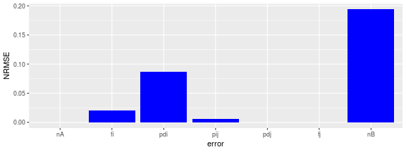

```r
plot_errors(solved)
```

Here enforcing pairing led to the propagation of errors to many other characteristics. For instance the average degrees of dwellings was adapted.

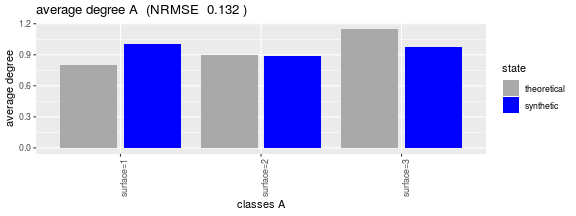

```r
plot_average_degree_A(solved)
```

We also can check what happens in detail to the distribution of degrees of probabilities, to analyze carefully which specific dwellings are concerned by this error. Here we observe the small dwellings have more links than planned (so there are less empy dwellings). There are also more empty dwellings than expected.

```r
# the modified distribution of degrees
solved$gen$hat.pdi
```

```
#>   surface=1  surface=2  surface=3
#> 0         0 0.15914530 0.19072100
#> 1         1 0.79139601 0.68150470
#> 2         0 0.04945869 0.08520376
#> 3         0 0.00000000 0.04257053
#> 4         0 0.00000000 0.00000000
```

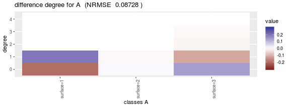

```r
# plot it
plot_errors_pdi(solved)
```

The plot of all errors also shown how the frequencies of classes for dwellings were biased. Let's display these frequencies \(f_i\), in order to analyze which are over or underrepresented.

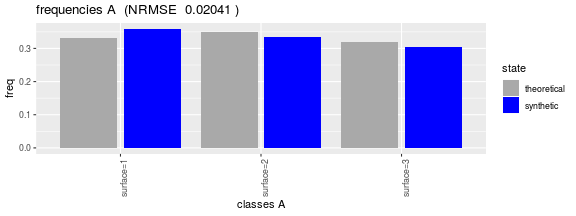

```r
plot_frequencies_A(solved)
```

## Actual generation

The actual generation actually creates the synthetic population from the computed parameters.

```r
sp <- matching.generate(
                     solved,
                     sample.A=dwellings_households$sample.A,
                     sample.B=dwellings_households$sample.B,
                     verbose=TRUE)
```

```
#> starting generation
#> copying population based on attributes 'surface=1,surface=2,surface=3' with 16500,17550,15950
#>  copying 16500 having surface=1
#>  should copy 16500 individuals for surface=1 and found 330 individuals with weights summing to 330
#>  copying 17550 having surface=2
#>  should copy 17550 individuals for surface=2 and found 351 individuals with weights summing to 351
#>  copying 15950 having surface=3
#>  should copy 15950 individuals for surface=3 and found 319 individuals with weights summing to 319
#> copying population based on attributes 'size=1,size=2,size=3,size=4' with 11300,11900,12200,12350
#>  copying 11300 having size=1
#>  should copy 11300 individuals for size=1 and found 228 individuals with weights summing to 117.4116
#>  copying 11900 having size=2
#>  should copy 11900 individuals for size=2 and found 194 individuals with weights summing to 95.41823
#>  copying 12200 having size=3
#>  should copy 12200 individuals for size=3 and found 210 individuals with weights summing to 111.2951
#>  copying 12350 having size=4
#>  should copy 12350 individuals for size=4 and found 202 individuals with weights summing to 103.3674
#>
#> adding target degrees for population A...
#>  set target degree 1  for 16500 over 16500    having surface=1
#>  set target degree 0  for 2793 over  17550    having surface=2
#>  set target degree 1  for 13889 over 14757    having surface=2
#>  set target degree 2  for 868 over   868  having surface=2
#>  set target degree 0  for 3042 over  15950    having surface=3
#>  set target degree 1  for 10870 over 12908    having surface=3
#>  set target degree 2  for 1359 over  2038     having surface=3
#>  set target degree 3  for 679 over   679  having surface=3
#>
#> adding target degrees for population B...
#>  set target degree 1  for 11300 over 11300    having size=1
#>  set target degree 1  for 11900 over 11900    having size=2
#>  set target degree 1  for 12200 over 12200    having size=3
#>  set target degree 1  for 12350 over 12350    having size=4
#>
#> matching A and B to create total 47750 links...
#>  should create 8800   links for A:    surface=1  and B:   size=1
#>  should create 4400   links for A:    surface=1  and B:   size=2
#>  should create 2200   links for A:    surface=1  and B:   size=3
#>  should create 1100   links for A:    surface=1  and B:   size=4
#>  should create 1875   links for A:    surface=2  and B:   size=1
#>  should create 6250   links for A:    surface=2  and B:   size=2
#>  should create 5000   links for A:    surface=2  and B:   size=3
#>  should create 2500   links for A:    surface=2  and B:   size=4
#>  should create 625    links for A:    surface=3  and B:   size=1
#>  should create 1250   links for A:    surface=3  and B:   size=2
#>  should create 5000   links for A:    surface=3  and B:   size=3
#>  should create 8750   links for A:    surface=3  and B:   size=4
```

The corresponding result contains three main tables (R data frames) which contain dwellings, households and links between them.

```r
sp
```

```
#> generation result
#> $pop
#> Synthetic population with 50000 parents, 47750 children, 47750 links
#>
#> $A (first lines)
#>      id surface cost.per.month id.A target.degree current.degree
#> 265 265       1              1    1             1              1
#> 252 252       1              2    2             1              1
#> 947 947       1              5    3             1              1
#> 681 681       1              4    4             1              1
#> 722 722       1             10    5             1              1
#> 760 760       1              8    6             1              1
#>
#> $B (first lines)
#>       size income  id.B target.degree current.degree
#> 690      1     10 50001             1              1
#> 92       1      4 50002             1              1
#> 699      1      5 50003             1              1
#> 395      1      8 50004             1              1
#> 571      1      9 50005             1              1
#> 699.1    1      5 50006             1              1
#>
#> $links (first lines)
#>     id.A  id.B
#> 1  11462 54450
#> 2  11340 51798
#> 3   8378 58924
#> 4   9179 58605
#> 5   6423 53871
#> 6   8001 50111
#> 7  15820 51302
#> 8   4781 51388
#> 9  15113 53805
#> 10  2596 50276
#> 11 13462 52220
#> 12 10318 52417
#> 13  1515 59744
#> 14  7662 56985
#> 15 13082 54625
#>
#> $measure
#> NULL
```

We can now access each data set using:

```r
head(sp$pop$A)
```

```
#>      id surface cost.per.month id.A target.degree current.degree
#> 265 265       1              1    1             1              1
#> 252 252       1              2    2             1              1
#> 947 947       1              5    3             1              1
#> 681 681       1              4    4             1              1
#> 722 722       1             10    5             1              1
#> 760 760       1              8    6             1              1
```

```r
head(sp$pop$B)
```

```
#>       size income  id.B target.degree current.degree
#> 690      1     10 50001             1              1
#> 92       1      4 50002             1              1
#> 699      1      5 50003             1              1
#> 395      1      8 50004             1              1
#> 571      1      9 50005             1              1
#> 699.1    1      5 50006             1              1
```

```r
head(sp$pop$links)
```

```
#>    id.A  id.B
#> 1 11462 54450
#> 2 11340 51798
#> 3  8378 58924
#> 4  9179 58605
#> 5  6423 53871
#> 6  8001 50111
```

## Assess the quality of the generation

Beyond the variables which are controlled by the algorithm, we can wonder what happened to variables which are not constrained. We provide a function for this plot:

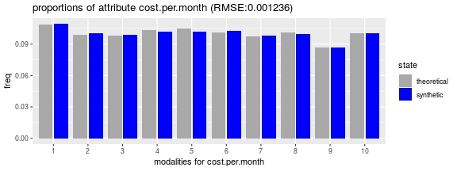

```r
plot_variable(sample=dwellings_households$sample.A, generated=sp$pop$A, var.name="cost.per.month")
```

## More

For more information, have a look to the conference papers related to this work, and to the other vignettes which describe the package.

This example was based on data already packaged with our method. A vignette should come soon which details how to apply this method on a real size case study from micro sample data.